# 6101 Project2

Xiaotian Huang

11/23/2019

```r
# can add quietly=T option to the require() function
loadPkg = function(x) { if (!require(x,character.only=T, quietly =T)) { install.packages(x,dep=T,repos="http://cran.us.r-project.org"); if(!require(x,character.only=T)) stop("Package not found") } }
```

## Chapter 1: Introduction of Cardiovascular Disease:

Based on The World Health Organization (WHO), Cardiovascular diseases (CVDs) are disorders related to the heart and blood vessels. The diseases mainly caused by fatty deposits plaque builds up on the inner walls of the blood vessels which prevent prevents blood from flowing to the heart or brain.

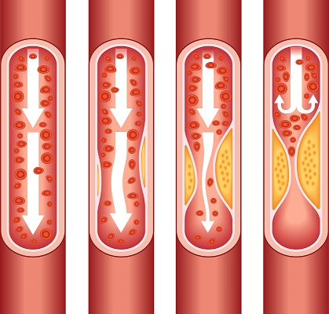

As plaque builds up in the arteries of a person with heart disease, the inside of the arteries begins to narrow, which lessens or blocks the flow of blood.

According to 2016 report, cardiovascular disease remains the leading cause of death in the United States (Benjamin et al., 2019). Around 80% of CVD deaths are a heart attack and stroke. The cause of cardiovascular diseases is usually the presence of a combination of risk factors, such as unhealthy diet, obesity, physical inactivity, tobacco use and harmful use of alcohol.

Since there are many reports indicated that the cause of cardiovascular diseases is associated with our lifestyle. Therefore, we want to use this dataset to validate a person’s behavior and developing of the disease.

## Chapter 2: Description of Data and Exploratory Data Analysis

### 2.1 Source Data

The source data for our EDA is a CSV containing 70 000 records of patients data in 12 features: age, height, weight, gender, systolic blood pressure, diastolic blood pressure, cholesterol, glucose, smoking, alcohol intake, physical activity, and presence or absence of cardiovascular disease. (https://www.kaggle.com/sulianova/cardiovascular-disease-dataset)

```
## 'data.frame':    70000 obs. of  13 variables:
##  $ id         : int  0 1 2 3 4 8 9 12 13 14 ...
##  $ age        : int  18393 20228 18857 17623 17474 21914 22113 22584 17668 19834 ...
##  $ gender     : Factor w/ 2 levels "1","2": 2 1 1 2 1 1 1 2 1 1 ...
##  $ height     : int  168 156 165 169 156 151 157 178 158 164 ...
##  $ weight     : num  62 85 64 82 56 67 93 95 71 68 ...
##  $ ap_hi      : int  110 140 130 150 100 120 130 130 110 110 ...
##  $ ap_lo      : int  80 90 70 100 60 80 80 90 70 60 ...
##  $ cholesterol: Factor w/ 3 levels "1","2","3": 1 3 3 1 1 2 3 3 1 1 ...
##  $ gluc       : Factor w/ 3 levels "1","2","3": 1 1 1 1 1 2 1 3 1 1 ...
##  $ smoke      : Factor w/ 2 levels "0","1": 1 1 1 1 1 1 1 1 1 1 ...
##  $ alco       : Factor w/ 2 levels "0","1": 1 1 1 1 1 1 1 1 1 1 ...
##  $ active     : Factor w/ 2 levels "0","1": 2 2 1 2 1 1 2 2 2 1 ...
##  $ cardio     : Factor w/ 2 levels "0","1": 1 2 2 2 1 1 1 2 1 1 ...
```

### 2.2 Preprocessing Data

We noticed that variable ‘age’ is int(day), which were converted into int(years).As height and weight individually do not mean much to patients’ health, so we calculated Body Mass Index (BMI), a measure of body fat based on height and weight that applies to adult men and women, and added it as a feature. Also column ‘id’ was droped.

```
##       age        gender        height          weight
##  Min.   :30.00   1:45530   Min.   : 55.0   Min.   : 10.00
##  1st Qu.:48.00   2:24470   1st Qu.:159.0   1st Qu.: 65.00
##  Median :54.00             Median :165.0   Median : 72.00
##  Mean   :53.34             Mean   :164.4   Mean   : 74.21
##  3rd Qu.:58.00             3rd Qu.:170.0   3rd Qu.: 82.00
##  Max.   :65.00             Max.   :250.0   Max.   :200.00
##      ap_hi             ap_lo          cholesterol gluc      smoke
##  Min.   : -150.0   Min.   :  -70.00   1:52385     1:59479   0:63831
##  1st Qu.:  120.0   1st Qu.:   80.00   2: 9549     2: 5190   1: 6169
##  Median :  120.0   Median :   80.00   3: 8066     3: 5331
##  Mean   :  128.8   Mean   :   96.63
##  3rd Qu.:  140.0   3rd Qu.:   90.00
##  Max.   :16020.0   Max.   :11000.00
##  alco      active    cardio         bmi
##  0:66236   0:13739   0:35021   Min.   :  3.472
##  1: 3764   1:56261   1:34979   1st Qu.: 23.875
##                                Median : 26.374
##                                Mean   : 27.557
##                                3rd Qu.: 30.222
##                                Max.   :298.667
```

We noticed that the min value of systolic blood pressure(ap_hi) and diastolic blood pressure (ap_lo) are negative values, which do not make sense. In addition, diastolic blood pressure is supposed to be lower than systolic blood pressure. The data were further cleaned based on these crterion.

Then the distribution of age, height, weight, ap_hi and ap_lo was checked.

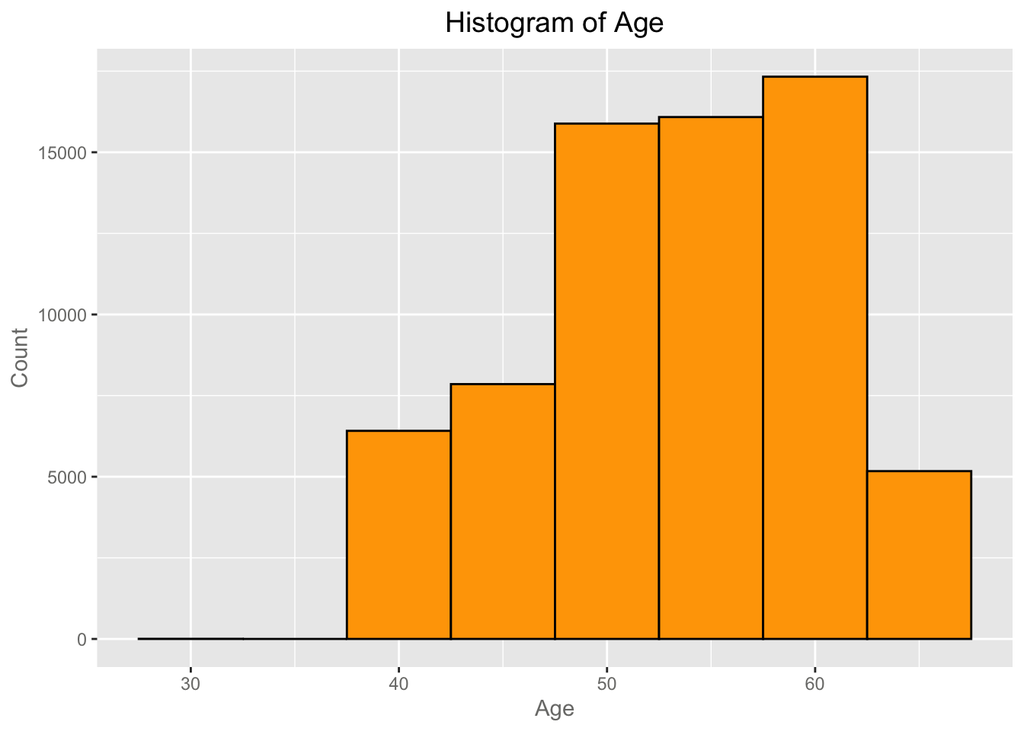

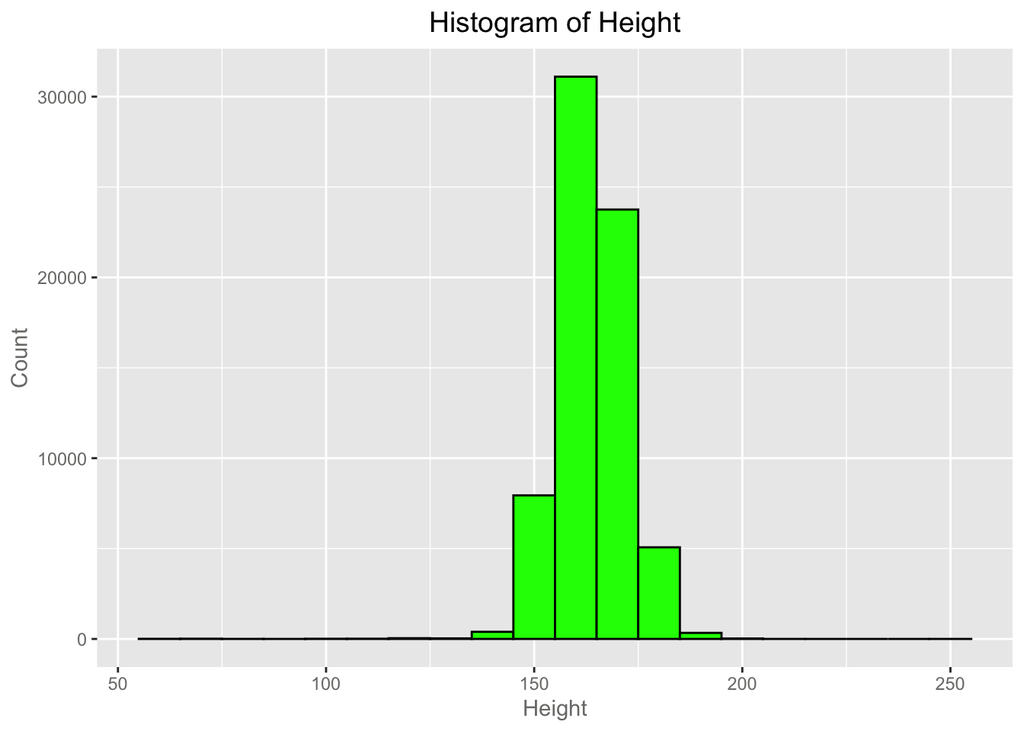

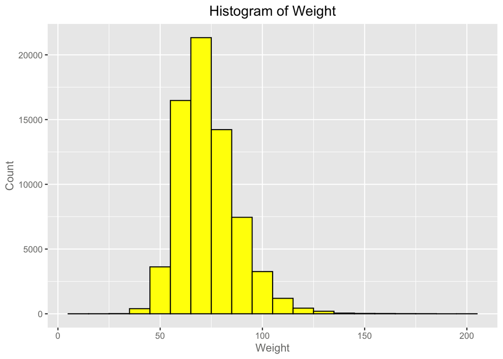

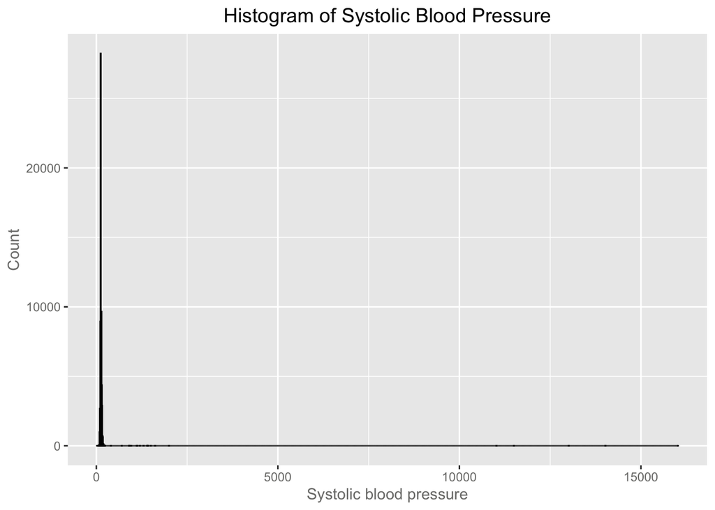

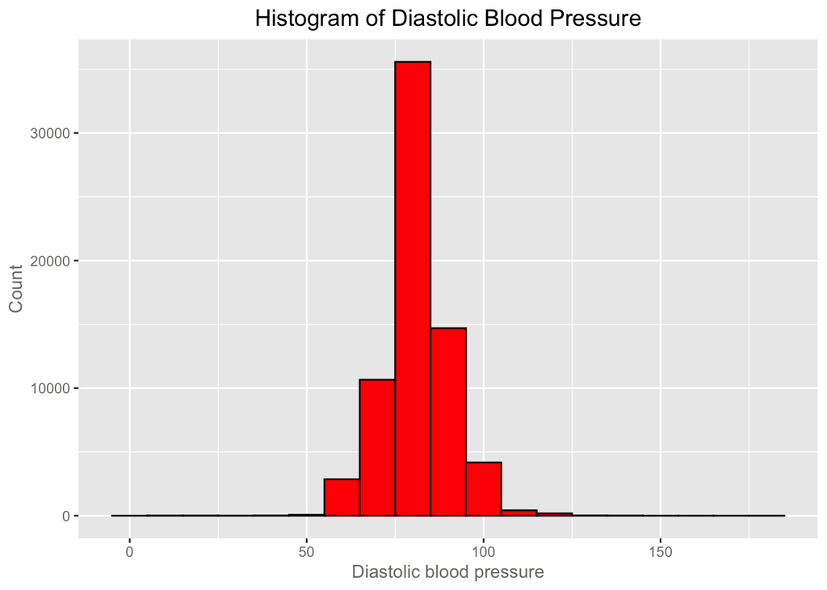

The histogram of age shows that there are only few observation for age<35, which could not represent the population of age<35, so the observations with age<35 were droped. For height, weight, ap_hi, and ap_lo, the histograms were way skewed by some extreme outliers, which were droped in this step.

The distribution of age, height, weight, ap_hi and ap_lo was checked again after outliers removed.

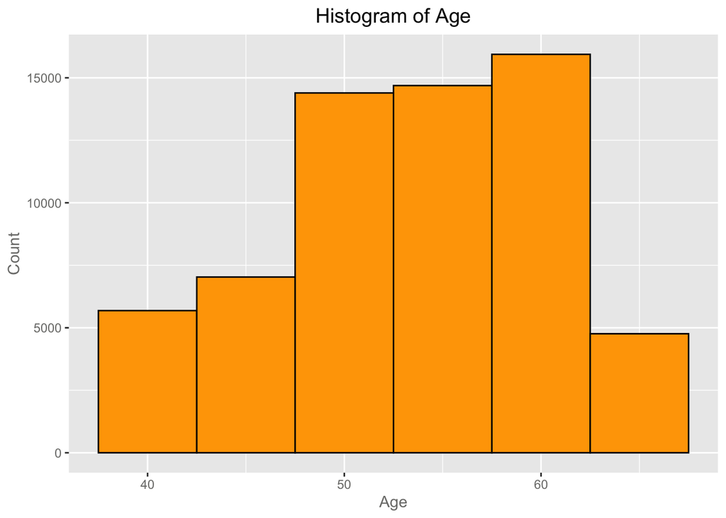

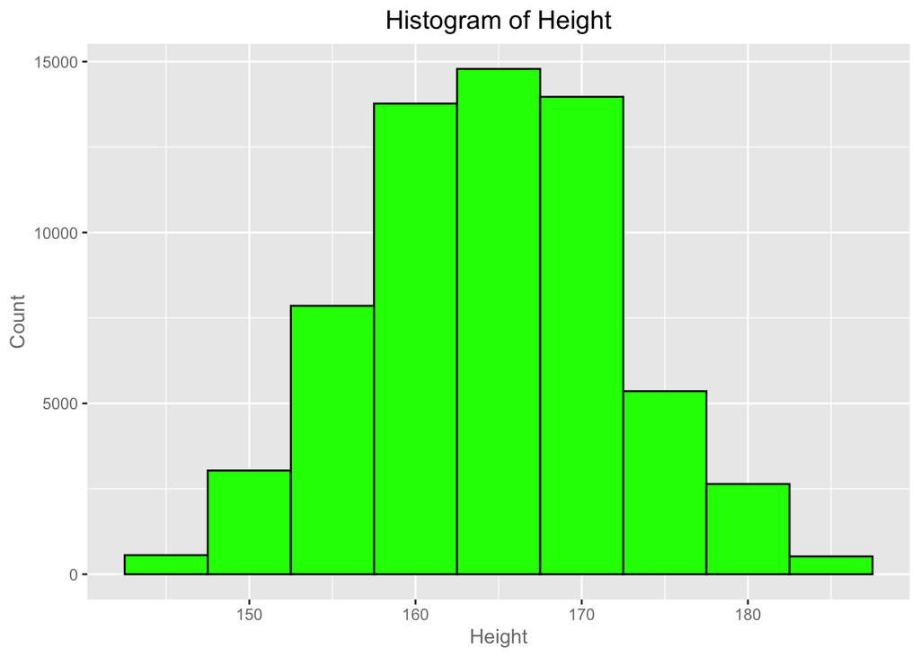

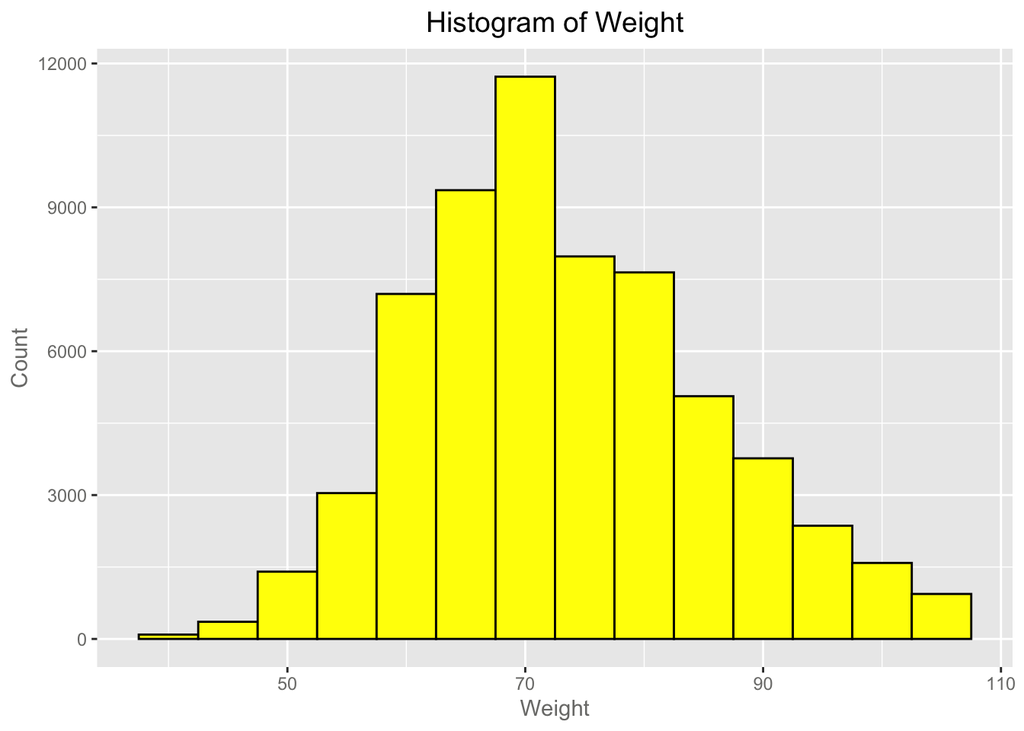

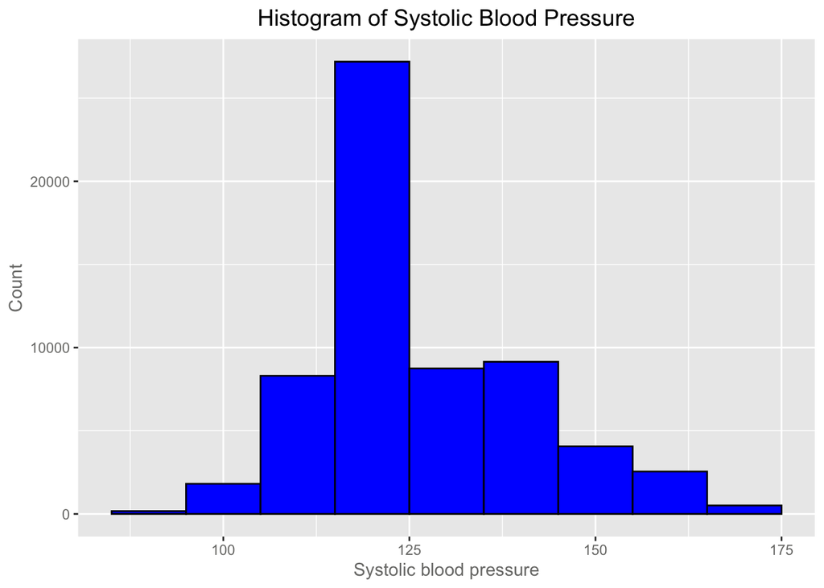

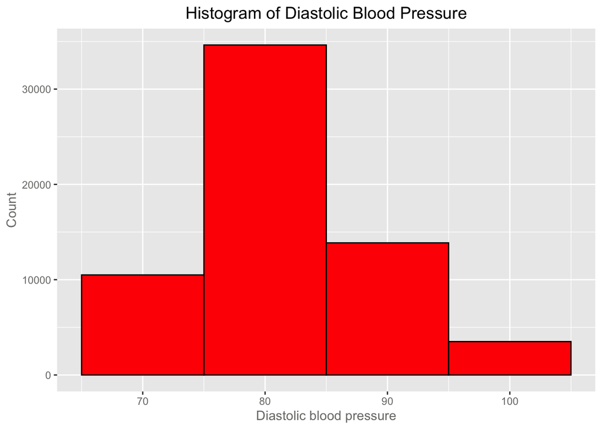

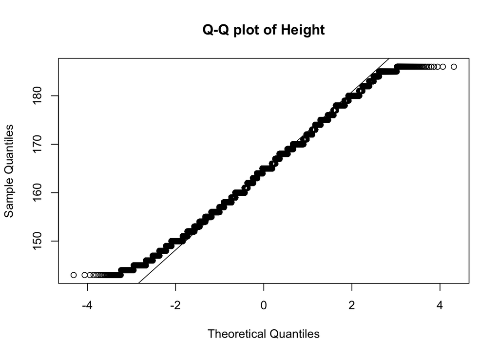

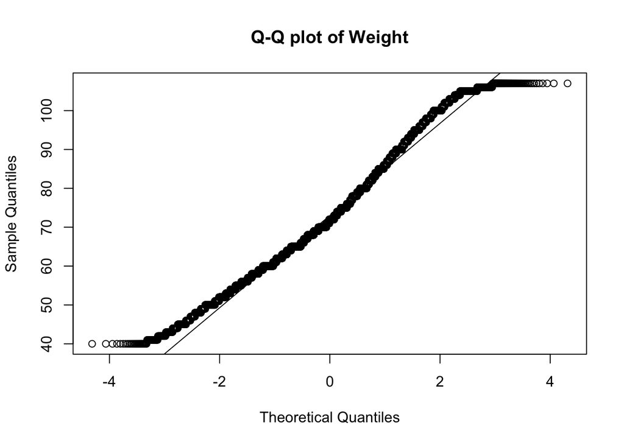

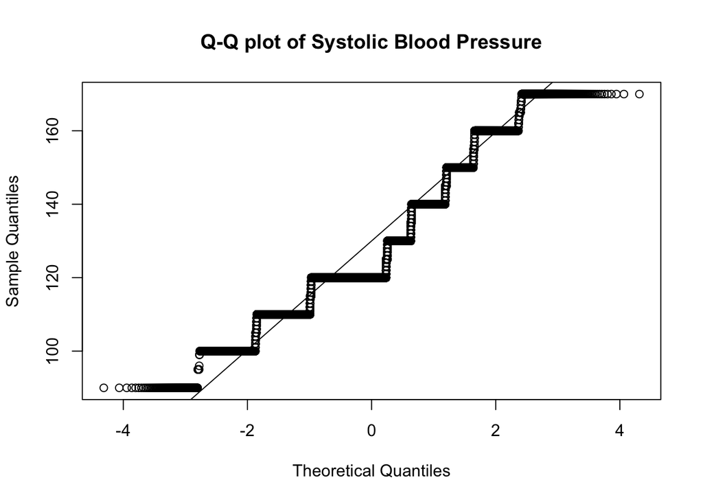

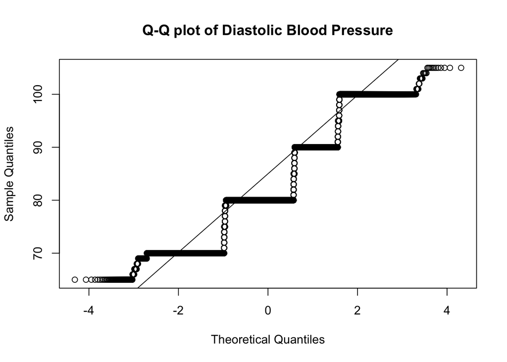

### Correlations among Different Variables

The correlation matrix was displayed to get an idea of the correlations among different variables.

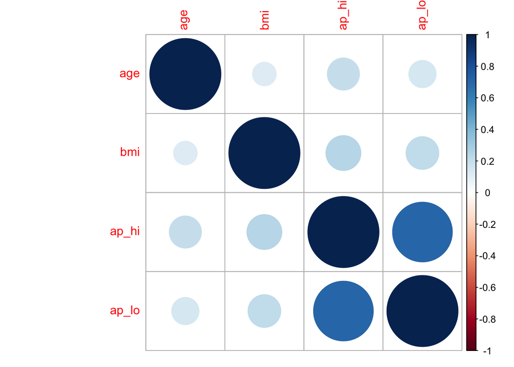

## Chapter 3: Cardio

### 3.1 SMART Question

What are the risk factors of cardiovascular diseases? Is age, height, weight, ap-hi, ap-lo correlated to the development of cardiovascular disease?

### 3.2.1 Basic analyze

```
##
## Call:
## glm(formula = cardio ~ age, family = "binomial", data = cardio)
##
## Deviance Residuals:
##     Min       1Q   Median       3Q      Max
## -1.5392  -1.1220  -0.7882   1.1099   1.6581
##
## Coefficients:
##              Estimate Std. Error z value Pr(>|z|)
## (Intercept) -3.936563   0.068325  -57.62   <2e-16 ***
## age          0.073168   0.001266   57.78   <2e-16 ***
## ---
## Signif. codes:  0 '***' 0.001 '**' 0.01 '*' 0.05 '.' 0.1 ' ' 1
##
## (Dispersion parameter for binomial family taken to be 1)
##
##     Null deviance: 86633  on 62498  degrees of freedom
## Residual deviance: 83073  on 62497  degrees of freedom
## AIC: 83077
##
## Number of Fisher Scoring iterations: 4
```

```
##
## Call:
## glm(formula = cardio ~ age + height + weight, family = "binomial",
##     data = cardio)
##
## Deviance Residuals:
##     Min       1Q   Median       3Q      Max
## -2.0597  -1.1027  -0.6555   1.1011   1.9556
##
## Coefficients:
##               Estimate Std. Error z value Pr(>|z|)
## (Intercept) -3.1994631  0.2018852  -15.85   <2e-16 ***
## age          0.0703877  0.0012887   54.62   <2e-16 ***
## height      -0.0167086  0.0011780  -14.18   <2e-16 ***
## weight       0.0295057  0.0007351   40.14   <2e-16 ***
## ---
## Signif. codes:  0 '***' 0.001 '**' 0.01 '*' 0.05 '.' 0.1 ' ' 1
##
## (Dispersion parameter for binomial family taken to be 1)
##
##     Null deviance: 86633  on 62498  degrees of freedom
## Residual deviance: 81397  on 62495  degrees of freedom
## AIC: 81405
##
## Number of Fisher Scoring iterations: 4
```

```
##
## Call:
## glm(formula = cardio ~ age + height + weight + ap_hi + ap_lo,
##     family = "binomial", data = cardio)
##
## Deviance Residuals:
##     Min       1Q   Median       3Q      Max
## -2.7864  -0.9453  -0.3945   0.9617   2.5558
##
## Coefficients:
##               Estimate Std. Error z value Pr(>|z|)
## (Intercept) -1.169e+01  2.474e-01 -47.244  < 2e-16 ***
## age          5.541e-02  1.402e-03  39.513  < 2e-16 ***
## height      -1.009e-02  1.284e-03  -7.853 4.06e-15 ***
## weight       1.410e-02  8.099e-04  17.415  < 2e-16 ***
## ap_hi        6.382e-02  1.040e-03  61.371  < 2e-16 ***
## ap_lo        1.587e-02  1.747e-03   9.081  < 2e-16 ***
## ---
## Signif. codes:  0 '***' 0.001 '**' 0.01 '*' 0.05 '.' 0.1 ' ' 1
##
## (Dispersion parameter for binomial family taken to be 1)
##
##     Null deviance: 86633  on 62498  degrees of freedom
## Residual deviance: 71454  on 62493  degrees of freedom
## AIC: 71466
##
## Number of Fisher Scoring iterations: 4
```

#### 3.2.2 ROC curve and AUC

```r
loadPkg("pROC")
prob=predict(cardiologit, type = c("response"))
cardio$prob=prob
h <- roc(cardio~prob, data=cardio)
```

```r
auc(h) # area-under-curve prefer 0.8 or higher.
```

```
## Area under the curve: 0.6349
```

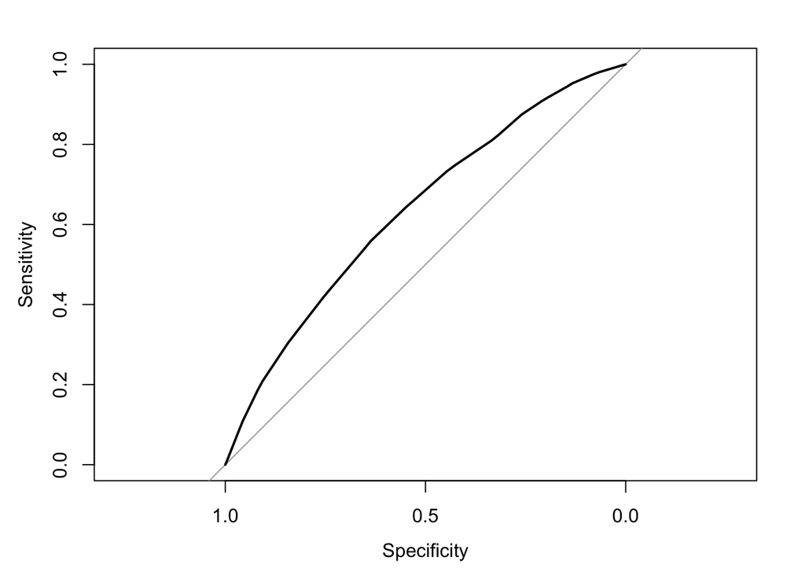

```r
plot(h)
```

```r
# detach("package:pROC", unload = T) # good habit to remove unload packages no longer needed
```

```r
loadPkg("pROC")
prob=predict(cardiologit2, type = c("response"))
cardio$prob=prob
h <- roc(cardio~prob, data=cardio)
```

```r
auc(h) # area-under-curve prefer 0.8 or higher.
```

```
## Area under the curve: 0.6627
```

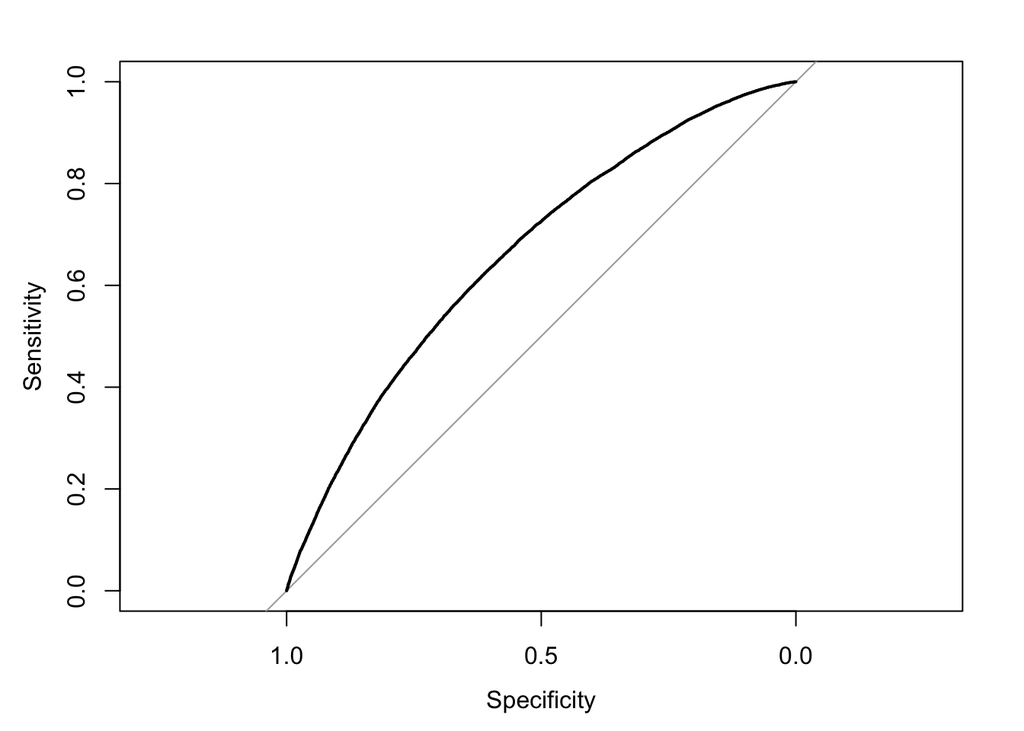

```r
plot(h)
```

```r
# detach("package:pROC", unload = T) # good habit to remove unload packages no longer needed
```

```r
loadPkg("pROC")
prob=predict(cardiologit3, type = c("response"))
cardio$prob=prob
h <- roc(cardio~prob, data=cardio)
```

```r
auc(h) # area-under-curve prefer 0.8 or higher.
```

```
## Area under the curve: 0.7762
```

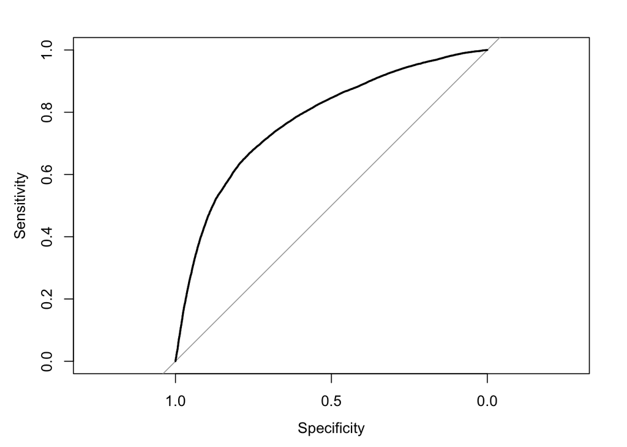

```r
plot(h)
```

```r
# detach("package:pROC", unload = T) # good habit to remove unload packages no longer needed
```

We have here the area-under-curve of 0.7761775, which is less than 0.8. This test agrees that the model is not considered a good fit.

#### 3.2.3 McFadden

```r
loadPkg("pscl")
```

```
## Classes and Methods for R developed in the
## Political Science Computational Laboratory
## Department of Political Science
## Stanford University
## Simon Jackman
## hurdle and zeroinfl functions by Achim Zeileis
```

```r
cardioLogitpr1 = pR2(cardiologit)
cardioLogitpr1
```

```
##           llh       llhNull            G2      McFadden          r2ML
## -4.153651e+04 -4.331635e+04  3.559680e+03  4.108934e-02  5.536418e-02
##          r2CU
##  7.382257e-02
```

```r
# detach("package:pscl", unload = T) # good habit to remove unload packages no longer needed
```

With the McFadden value of 0.0410893, which is analgous to the coefficient of determination R$2$, only about 4% of the variations in y is explained by the explanatory variables in the model.

A major weakness of the overall model is likely from the small dataset sample size of 62499. We expect a much higher number of observations will increase the sensitivity of the model.

```r
loadPkg("pscl")
cardioLogitpr2 = pR2(cardiologit2)
cardioLogitpr2
```

```
##           llh       llhNull            G2      McFadden          r2ML
## -4.069849e+04 -4.331635e+04  5.235709e+03  6.043572e-02  8.035973e-02
##          r2CU
##  1.071516e-01
```

With the McFadden value of 0.0604357, which is analgous to the coefficient of determination R$2$, only about 6% of the variations in y is explained by the explanatory variables in the model.

A major weakness of the overall model is likely from the small dataset sample size of 62499. We expect a much higher number of observations will increase the sensitivity of the model.

```r
loadPkg("pscl")
cardioLogitpr3 = pR2(cardiologit3)
cardioLogitpr3
```

```
##           llh       llhNull            G2      McFadden          r2ML
## -3.572688e+04 -4.331635e+04  1.517894e+04  1.752103e-01  2.156241e-01
##          r2CU
##  2.875131e-01
```

## Chapter 4: PCA

### 4.2 Basic analyze

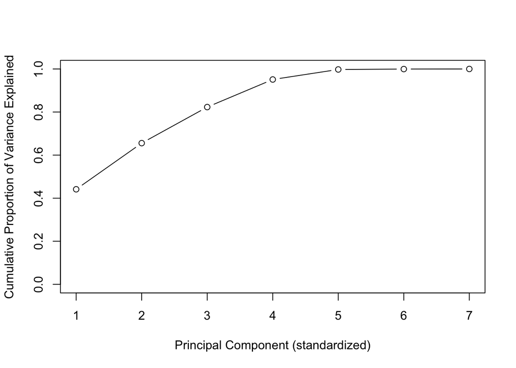

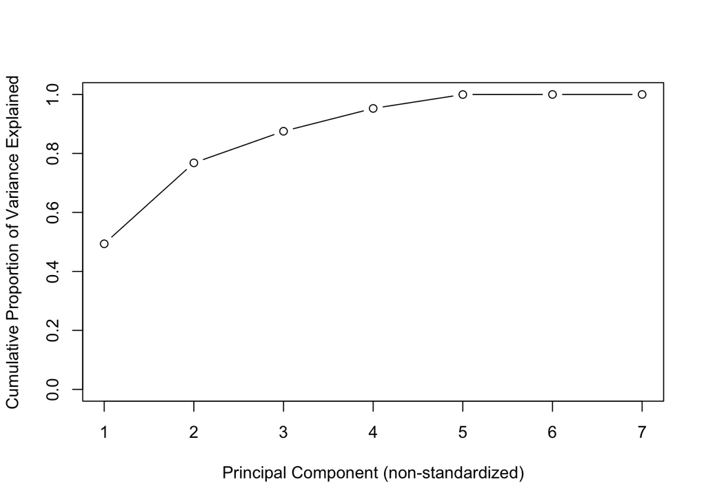

## Chapter 5: KNN

```
##   age gender height weight ap_hi ap_lo cholesterol gluc smoke alco active
## 1  50      2    168     62   110    80           1    1     0    0      1
## 2  55      1    156     85   140    90           3    1     0    0      1
## 3  52      1    165     64   130    70           3    1     0    0      0
## 4  48      2    169     82   150   100           1    1     0    0      1
## 6  60      1    151     67   120    80           2    2     0    0      0
## 7  61      1    157     93   130    80           3    1     0    0      1
##   cardio      bmi      prob
## 1      0 21.96712 0.1905680
## 2      1 34.92768 0.7940517
## 3      1 23.50781 0.4602791
## 4      1 28.71048 0.8299230
## 6      0 29.38468 0.4970053
## 7      0 37.72973 0.7286665
```

```
## 'data.frame':    62499 obs. of  14 variables:
##  $ age        : num  50 55 52 48 60 61 62 48 62 52 ...
##  $ gender     : Factor w/ 2 levels "1","2": 2 1 1 2 1 1 2 1 1 2 ...
##  $ height     : int  168 156 165 169 151 157 178 158 169 173 ...
##  $ weight     : num  62 85 64 82 67 93 95 71 80 60 ...
##  $ ap_hi      : int  110 140 130 150 120 130 130 110 120 120 ...
##  $ ap_lo      : int  80 90 70 100 80 80 90 70 80 80 ...
##  $ cholesterol: Factor w/ 3 levels "1","2","3": 1 3 3 1 2 3 3 1 1 1 ...
##  $ gluc       : Factor w/ 3 levels "1","2","3": 1 1 1 1 2 1 3 1 1 1 ...
##  $ smoke      : Factor w/ 2 levels "0","1": 1 1 1 1 1 1 1 1 1 1 ...
##  $ alco       : Factor w/ 2 levels "0","1": 1 1 1 1 1 1 1 1 1 1 ...
##  $ active     : Factor w/ 2 levels "0","1": 2 2 1 2 1 2 2 2 2 2 ...
##  $ cardio     : Factor w/ 2 levels "0","1": 1 2 2 2 1 1 2 1 1 1 ...
##  $ bmi        : num  22 34.9 23.5 28.7 29.4 ...
##  $ prob       : num  0.191 0.794 0.46 0.83 0.497 ...
##  - attr(*, "na.action")= 'omit' Named int  5 10 16 24 44 51 57 60 62 63 ...
##   ..- attr(*, "names")= chr  "5" "10" "16" "24" ...
```

```
##       age        gender        height          weight
##  Min.   :39.00   1:40715   Min.   :143.0   Min.   : 40.00
##  1st Qu.:49.00   2:21784   1st Qu.:159.0   1st Qu.: 65.00
##  Median :54.00             Median :165.0   Median : 72.00
##  Mean   :53.41             Mean   :164.4   Mean   : 73.18
##  3rd Qu.:58.00             3rd Qu.:170.0   3rd Qu.: 81.00
##  Max.   :65.00             Max.   :186.0   Max.   :107.00
##      ap_hi           ap_lo       cholesterol gluc      smoke     alco
##  Min.   : 90.0   Min.   : 65.0   1:47208     1:53402   0:57103   0:59239
##  1st Qu.:120.0   1st Qu.: 80.0   2: 8224     2: 4403   1: 5396   1: 3260
##  Median :120.0   Median : 80.0   3: 7067     3: 4694
##  Mean   :126.4   Mean   : 81.7
##  3rd Qu.:140.0   3rd Qu.: 90.0
##  Max.   :170.0   Max.   :105.0
##  active    cardio         bmi             prob
##  0:12229   0:31631   Min.   :13.52   Min.   :0.02508
##  1:50270   1:30868   1st Qu.:23.88   1st Qu.:0.31176
##                      Median :26.23   Median :0.45328
##                      Mean   :27.12   Mean   :0.49390
##                      3rd Qu.:29.76   3rd Qu.:0.68939
##                      Max.   :50.89   Max.   :0.98532
```

[output not shown]

[output cut: 541 more lines]

```
##
##
##    Cell Contents
## |-------------------------|
## |                       N |
## |           N / Row Total |
## |           N / Col Total |
## |         N / Table Total |
## |-------------------------|
##
##
## Total Observations in Table:  18841
##
##
##                   | cardio_pred
## cardio.testLabels |         0 |         1 | Row Total |
## ------------------|-----------|-----------|-----------|
##                 0 |      7077 |      2400 |      9477 |
##                   |     0.747 |     0.253 |     0.503 |
##                   |     0.649 |     0.302 |           |
##                   |     0.376 |     0.127 |           |
## ------------------|-----------|-----------|-----------|
##                 1 |      3827 |      5537 |      9364 |
##                   |     0.409 |     0.591 |     0.497 |
##                   |     0.351 |     0.698 |           |
##                   |     0.203 |     0.294 |           |
## ------------------|-----------|-----------|-----------|
##      Column Total |     10904 |      7937 |     18841 |
##                   |     0.579 |     0.421 |           |
## ------------------|-----------|-----------|-----------|
##
##
```

[output not shown]

[output cut: 541 more lines]

```
##
##
##    Cell Contents
## |-------------------------|
## |                       N |
## |           N / Row Total |
## |           N / Col Total |
## |         N / Table Total |
## |-------------------------|
##
##
## Total Observations in Table:  18841
##
##
##                   | cardio_pred1
## cardio.testLabels |         0 |         1 | Row Total |
## ------------------|-----------|-----------|-----------|
##                 0 |      7189 |      2288 |      9477 |
##                   |     0.759 |     0.241 |     0.503 |
##                   |     0.657 |     0.289 |           |
##                   |     0.382 |     0.121 |           |
## ------------------|-----------|-----------|-----------|
##                 1 |      3745 |      5619 |      9364 |
##                   |     0.400 |     0.600 |     0.497 |
##                   |     0.343 |     0.711 |           |
##                   |     0.199 |     0.298 |           |
## ------------------|-----------|-----------|-----------|
##      Column Total |     10934 |      7907 |     18841 |
##                   |     0.580 |     0.420 |           |
## ------------------|-----------|-----------|-----------|
##
##
```

[output not shown]

[output cut: 541 more lines]

```
##
##
##    Cell Contents
## |-------------------------|
## |                       N |
## |           N / Row Total |
## |           N / Col Total |
## |         N / Table Total |
## |-------------------------|
##
##
## Total Observations in Table:  18841
##
##
##                   | cardio_pred2
## cardio.testLabels |         0 |         1 | Row Total |
## ------------------|-----------|-----------|-----------|
##                 0 |      7261 |      2216 |      9477 |
##                   |     0.766 |     0.234 |     0.503 |
##                   |     0.665 |     0.280 |           |
##                   |     0.385 |     0.118 |           |
## ------------------|-----------|-----------|-----------|
##                 1 |      3657 |      5707 |      9364 |
##                   |     0.391 |     0.609 |     0.497 |
##                   |     0.335 |     0.720 |           |
##                   |     0.194 |     0.303 |           |
## ------------------|-----------|-----------|-----------|
##      Column Total |     10918 |      7923 |     18841 |
##                   |     0.579 |     0.421 |           |
## ------------------|-----------|-----------|-----------|
##
##
```

```
##
## cardio_3NN    0    1
##          0 6623 3236
##          1 2950 5941
```

```
## [1] 18750
```

```
## [1] 6623 5941
```

```
## [1] 0.67008
```

```
##
## cardio_6NN    0    1
##          0 6864 3114
##          1 2709 6063
```

```
## [1] 18750
```

```
## [1] 6864 6063
```

```
## [1] 0.68944
```

```
##
## cardio_9NN    0    1
##          0 6995 3026
##          1 2578 6151
```

```
## [1] 18750
```

```
## [1] 6995 6151
```

```
## [1] 0.70112
```